# Unsupervised Learning_Customer_Segmentation_Silambarasan

```python
import numpy as np
import pandas as pd
from scipy import stats
from scipy.stats import zscore
import matplotlib.pyplot as plt
%matplotlib inline
import seaborn as sns
import warnings
warnings.filterwarnings('ignore')
```

```python
# Import the dataset - Reading datafile as Dataframe called bankdata

bankdata=pd.read_csv("CreditCardCustomer.csv")
```

```python
bankdata.head()
```

|  | Sl_No | Customer Key | Avg_Credit_Limit | Total_Credit_Cards | Total_visits_bank | Total_visits_online | Total_calls_made |
| --- | --- | --- | --- | --- | --- | --- | --- |
| 0 | 1 | 87073 | 100000 | 2 | 1 | 1 | 0 |
| 1 | 2 | 38414 | 50000 | 3 | 0 | 10 | 9 |
| 2 | 3 | 17341 | 50000 | 7 | 1 | 3 | 4 |
| 3 | 4 | 40496 | 30000 | 5 | 1 | 1 | 4 |
| 4 | 5 | 47437 | 100000 | 6 | 0 | 12 | 3 |

```python
# Dataframe shape - Get the number of rows and columns available in dataframe

bankdata.shape

print("Total number of rows ")
print( bankdata.shape[0])
print("Total number of Columns ")
print( bankdata.shape[1])
```

```
Total number of rows
660
Total number of Columns
7
```

```python
# Get the column names, number of non-null values and data-type for each column

bankdata.info()
```

```
<class 'pandas.core.frame.DataFrame'>
RangeIndex: 660 entries, 0 to 659
Data columns (total 7 columns):
 #   Column               Non-Null Count  Dtype
---  ------               --------------  -----
 0   Sl_No                660 non-null    int64
 1   Customer Key         660 non-null    int64
 2   Avg_Credit_Limit     660 non-null    int64
 3   Total_Credit_Cards   660 non-null    int64
 4   Total_visits_bank    660 non-null    int64
 5   Total_visits_online  660 non-null    int64
 6   Total_calls_made     660 non-null    int64
dtypes: int64(7)
memory usage: 36.2 KB
```

Inferences:

```
i.  All variables are integer data types
ii. No Null values/missing values exist
```

```python
# Checking for Duplicate Values

bankdata.duplicated().sum()

#Inference: No duplicates
```

```
0
```

```python
# Dataframe statistical summary

bankdata.describe().T
```

|  | count | mean | std | min | 25% | 50% | 75% | max |
| --- | --- | --- | --- | --- | --- | --- | --- | --- |
| Sl_No | 660.0 | 330.500000 | 190.669872 | 1.0 | 165.75 | 330.5 | 495.25 | 660.0 |
| Customer Key | 660.0 | 55141.443939 | 25627.772200 | 11265.0 | 33825.25 | 53874.5 | 77202.50 | 99843.0 |
| Avg_Credit_Limit | 660.0 | 34574.242424 | 37625.487804 | 3000.0 | 10000.00 | 18000.0 | 48000.00 | 200000.0 |
| Total_Credit_Cards | 660.0 | 4.706061 | 2.167835 | 1.0 | 3.00 | 5.0 | 6.00 | 10.0 |
| Total_visits_bank | 660.0 | 2.403030 | 1.631813 | 0.0 | 1.00 | 2.0 | 4.00 | 5.0 |
| Total_visits_online | 660.0 | 2.606061 | 2.935724 | 0.0 | 1.00 | 2.0 | 4.00 | 15.0 |
| Total_calls_made | 660.0 | 3.583333 | 2.865317 | 0.0 | 1.00 | 3.0 | 5.00 | 10.0 |

Inferences:

1. 3rd quartile(75%) of Avg_Credit_Limit is 48,000 whereas max value is 200000.0. Probability of having outlier is more. lets find out

```python
# Dropping serial number and customer key columns since both features have no significance
df=bankdata.drop(['Sl_No','Customer Key'], axis=1)
```

```python
# Viewing first 5 rows
df.head()
```

|  | Avg_Credit_Limit | Total_Credit_Cards | Total_visits_bank | Total_visits_online | Total_calls_made |
| --- | --- | --- | --- | --- | --- |
| 0 | 100000 | 2 | 1 | 1 | 0 |
| 1 | 50000 | 3 | 0 | 10 | 9 |
| 2 | 50000 | 7 | 1 | 3 | 4 |
| 3 | 30000 | 5 | 1 | 1 | 4 |
| 4 | 100000 | 6 | 0 | 12 | 3 |

#### Attribute: Avg_Credit_Limit

```python
#Outlier detection from Interquartile range (IQR) in original data

Q1=df['Avg_Credit_Limit'].quantile(q=0.25) # 1st Quartile
Q3=df['Avg_Credit_Limit'].quantile(q=0.75) #3rd Quartile
L_outliers=Q1-1.5*(Q3-Q1)# Lower Outliers
U_outliers=Q3+1.5*(Q3-Q1)#Upper Outliers
print('Lower outliers in Avg_Credit_Limit: ', L_outliers)
print('Upper outliers in Avg_Credit_Limit ', U_outliers)
```

```
Lower outliers in Avg_Credit_Limit:  -47000.0
Upper outliers in Avg_Credit_Limit  105000.0
```

```python
print('Number of upper outliers in Avg_Credit_Limit: ', df[df['Avg_Credit_Limit']>105000]['Avg_Credit_Limit'].count())
print('Number of lower outliers in Avg_Credit_Limit: ', df[df['Avg_Credit_Limit']<-47000]['Avg_Credit_Limit'].count())
print('% of upper outlier in Avg_Credit_Limit: ',round(df[df['Avg_Credit_Limit']>105000]['Avg_Credit_Limit'].count()*100/len(df)), '%')
print('% of lower Outlier in Avg_Credit_Limit: ',round(df[df['Avg_Credit_Limit']<-47000]['Avg_Credit_Limit'].count()*100/len(df)), '%')
```

```
Number of upper outliers in Avg_Credit_Limit:  39
Number of lower outliers in Avg_Credit_Limit:  0
% of upper outlier in Avg_Credit_Limit:  6.0 %
% of lower Outlier in Avg_Credit_Limit:  0.0 %
```

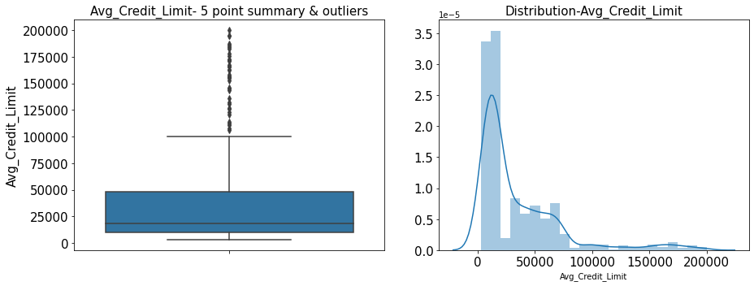

```python
fig, (ax1,ax2)=plt.subplots(1,2,figsize=(13,5))
#boxplot
sns.boxplot(x='Avg_Credit_Limit',data=df,orient='v',ax=ax1)
ax1.set_ylabel('Avg_Credit_Limit', fontsize=15)
ax1.set_title('Avg_Credit_Limit- 5 point summary & outliers', fontsize=15)
ax1.tick_params(labelsize=15)

#distplot
sns.distplot(df['Avg_Credit_Limit'],ax=ax2)
ax2.set_title('Distribution-Avg_Credit_Limit', fontsize=15)
ax2.tick_params(labelsize=15)

plt.subplots_adjust(wspace=0.5)
plt.tight_layout()
plt.show()
```

#### Attribute:Total_Credit_Cards

```python
#### Outlier detection from Interquartile range (IQR) in original data

Q1=df['Total_Credit_Cards'].quantile(q=0.25) # 1st Quartile
Q3=df['Total_Credit_Cards'].quantile(q=0.75) #3rd Quartile
L_outliers=Q1-1.5*(Q3-Q1)# Lower Outliers
U_outliers=Q3+1.5*(Q3-Q1)#Upper Outliers
print('Lower outliers in Total_Credit_Cards: ', L_outliers)
print('Upper outliers in Total_Credit_Cards ', U_outliers)
```

```
Lower outliers in Total_Credit_Cards:  -1.5
Upper outliers in Total_Credit_Cards  10.5
```

```python
print('Number of upper outliers in Total_Credit_Cards: ', df[df['Total_Credit_Cards']>10.5]['Total_Credit_Cards'].count())
print('Number of lower outliers in Total_Credit_Cards: ', df[df['Total_Credit_Cards']<-1.5]['Total_Credit_Cards'].count())
print('% of upper outlier in Total_Credit_Cards: ',round(df[df['Total_Credit_Cards']>10.5]['Total_Credit_Cards'].count()*100/len(df)), '%')
print('% of lower Outlier in Total_Credit_Cards: ',round(df[df['Total_Credit_Cards']<-1.5]['Total_Credit_Cards'].count()*100/len(df)), '%')
```

```
Number of upper outliers in Total_Credit_Cards:  0
Number of lower outliers in Total_Credit_Cards:  0
% of upper outlier in Total_Credit_Cards:  0.0 %
% of lower Outlier in Total_Credit_Cards:  0.0 %
```

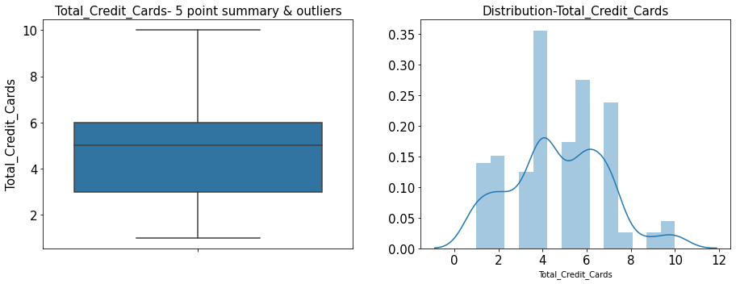

```python
fig, (ax1,ax2)=plt.subplots(1,2,figsize=(13,5))
#boxplot
sns.boxplot(x='Total_Credit_Cards',data=df,orient='v',ax=ax1)
ax1.set_ylabel('Total_Credit_Cards', fontsize=15)
ax1.set_title('Total_Credit_Cards- 5 point summary & outliers', fontsize=15)
ax1.tick_params(labelsize=15)

#distplot
sns.distplot(df['Total_Credit_Cards'],ax=ax2)
ax2.set_title('Distribution-Total_Credit_Cards', fontsize=15)
ax2.tick_params(labelsize=15)

plt.subplots_adjust(wspace=0.5)
plt.tight_layout()
plt.show()
```

#### Attribute:Total_visits_bank

```python
#### Outlier detection from Interquartile range (IQR) in original data

Q1=df['Total_visits_bank'].quantile(q=0.25) # 1st Quartile
Q3=df['Total_visits_bank'].quantile(q=0.75) #3rd Quartile
L_outliers=Q1-1.5*(Q3-Q1)# Lower Outliers
U_outliers=Q3+1.5*(Q3-Q1)#Upper Outliers
print('Lower outliers in Total_visits_bank: ', L_outliers)
print('Upper outliers in Total_visits_bank: ', U_outliers)
```

```
Lower outliers in Total_visits_bank:  -3.5
Upper outliers in Total_visits_bank:  8.5
```

```python
print('Number of upper outliers in Total_visits_bank: ', df[df['Total_visits_bank']>8.5]['Total_visits_bank'].count())
print('Number of lower outliers in Total_visits_bank: ', df[df['Total_visits_bank']<-3.5]['Total_visits_bank'].count())
print('% of upper outlier in Total_visits_bank: ',round(df[df['Total_visits_bank']>8.5]['Total_visits_bank'].count()*100/len(df)), '%')
print('% of lower Outlier in Total_visits_bank: ',round(df[df['Total_visits_bank']<-3.5]['Total_visits_bank'].count()*100/len(df)), '%')
```

```
Number of upper outliers in Total_visits_bank:  0
Number of lower outliers in Total_visits_bank:  0
% of upper outlier in Total_visits_bank:  0.0 %
% of lower Outlier in Total_visits_bank:  0.0 %
```

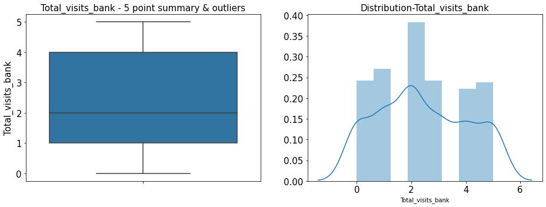

```python
fig, (ax1,ax2)=plt.subplots(1,2,figsize=(13,5))
#boxplot
sns.boxplot(x='Total_visits_bank',data=df,orient='v',ax=ax1)
ax1.set_ylabel('Total_visits_bank', fontsize=15)
ax1.set_title('Total_visits_bank - 5 point summary & outliers', fontsize=15)
ax1.tick_params(labelsize=15)

#distplot
sns.distplot(df['Total_visits_bank'],ax=ax2)
ax2.set_title('Distribution-Total_visits_bank', fontsize=15)
ax2.tick_params(labelsize=15)

plt.subplots_adjust(wspace=0.5)
plt.tight_layout()
plt.show()
```

#### Attribute: Total_visits_online

```python
#### Outlier detection from Interquartile range (IQR) in original data

Q1=df['Total_visits_online'].quantile(q=0.25) # 1st Quartile
Q3=df['Total_visits_online'].quantile(q=0.75) #3rd Quartile
L_outliers=Q1-1.5*(Q3-Q1)# Lower Outliers
U_outliers=Q3+1.5*(Q3-Q1)#Upper Outliers
print('Lower outliers in Total_visits_online: ', L_outliers)
print('Upper outliers in Total_visits_online: ', U_outliers)
```

```
Lower outliers in Total_visits_online:  -3.5
Upper outliers in Total_visits_online:  8.5
```

```python
print('Number of upper outliers in Total_visits_online: ', df[df['Total_visits_online']>8.5]['Total_visits_online'].count())
print('Number of lower outliers in Total_visits_online: ', df[df['Total_visits_online']<-3.5]['Total_visits_online'].count())
print('% of upper outlier in Total_visits_online: ',round(df[df['Total_visits_online']>8.5]['Total_visits_online'].count()*100/len(df)), '%')
print('% of lower Outlier in Total_visits_online: ',round(df[df['Total_visits_online']<-3.5]['Total_visits_online'].count()*100/len(df)), '%')
```

```
Number of upper outliers in Total_visits_online:  37
Number of lower outliers in Total_visits_online:  0
% of upper outlier in Total_visits_online:  6.0 %
% of lower Outlier in Total_visits_online:  0.0 %
```

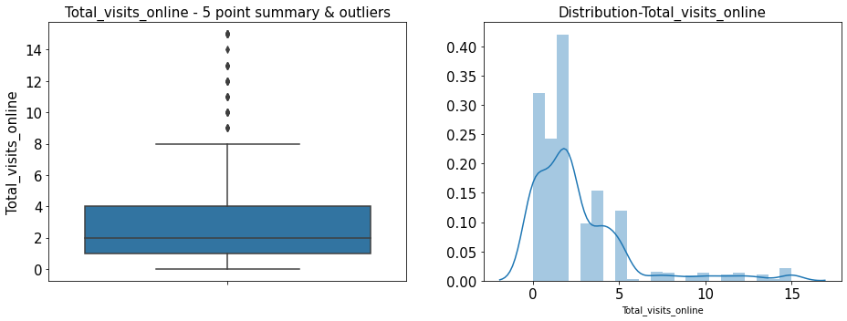

```python
fig, (ax1,ax2)=plt.subplots(1,2,figsize=(13,5))
#boxplot
sns.boxplot(x='Total_visits_online',data=df,orient='v',ax=ax1)
ax1.set_ylabel('Total_visits_online', fontsize=15)
ax1.set_title('Total_visits_online - 5 point summary & outliers', fontsize=15)
ax1.tick_params(labelsize=15)

#distplot
sns.distplot(df['Total_visits_online'],ax=ax2)
ax2.set_title('Distribution-Total_visits_online', fontsize=15)
ax2.tick_params(labelsize=15)

plt.subplots_adjust(wspace=0.5)
plt.tight_layout()
plt.show()
```

#### Attribute: Total_calls_made

```python
#### Outlier detection from Interquartile range (IQR) in original data

Q1=df['Total_calls_made'].quantile(q=0.25) # 1st Quartile
Q3=df['Total_calls_made'].quantile(q=0.75) #3rd Quartile
L_outliers=Q1-1.5*(Q3-Q1)# Lower Outliers
U_outliers=Q3+1.5*(Q3-Q1)#Upper Outliers
print('Lower outliers in Total_calls_made: ', L_outliers)
print('Upper outliers in Total_calls_made: ', U_outliers)
```

```
Lower outliers in Total_calls_made:  -5.0
Upper outliers in Total_calls_made:  11.0
```

```python
print('Number of upper outliers in Total_calls_made: ', df[df['Total_calls_made']>11.0]['Total_calls_made'].count())
print('Number of lower outliers in Total_calls_made: ', df[df['Total_calls_made']<-5.0]['Total_calls_made'].count())
print('% of upper outlier in Total_calls_made: ',round(df[df['Total_calls_made']>11.0]['Total_calls_made'].count()*100/len(df)), '%')
print('% of lower Outlier in Total_calls_made: ',round(df[df['Total_calls_made']<-5.0]['Total_calls_made'].count()*100/len(df)), '%')
```

```
Number of upper outliers in Total_calls_made:  0
Number of lower outliers in Total_calls_made:  0
% of upper outlier in Total_calls_made:  0.0 %
% of lower Outlier in Total_calls_made:  0.0 %
```

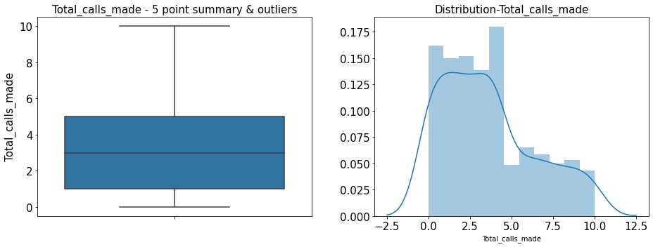

```python
fig, (ax1,ax2)=plt.subplots(1,2,figsize=(13,5))
#boxplot
sns.boxplot(x='Total_calls_made',data=df,orient='v',ax=ax1)
ax1.set_ylabel('Total_calls_made', fontsize=15)
ax1.set_title('Total_calls_made - 5 point summary & outliers', fontsize=15)
ax1.tick_params(labelsize=15)

#distplot
sns.distplot(df['Total_calls_made'],ax=ax2)
ax2.set_title('Distribution-Total_calls_made', fontsize=15)
ax2.tick_params(labelsize=15)

plt.subplots_adjust(wspace=0.5)
plt.tight_layout()
plt.show()
```

Inference: Outliers exist in 2 features-Total_visits_online &Avg_Credit_Limit

```python
#Outliers Treatment

# Let us take logaritmic transform for Total_visits_online and Avg_Credit_Limit to remove outliers
df['Total_visits_online'] = np.log1p(df['Total_visits_online'])
df['Avg_Credit_Limit'] = np.log1p(df['Avg_Credit_Limit'])
```

```python
# skewness

df.skew()
```

```
Avg_Credit_Limit       0.393822
Total_Credit_Cards     0.144879
Total_visits_bank      0.141896
Total_visits_online    0.170883
Total_calls_made       0.658905
dtype: float64
```

Inference: The skewness value should be btw -1 and 1 if the data is normally distributed. All columns are normally distributed after outlier treatment

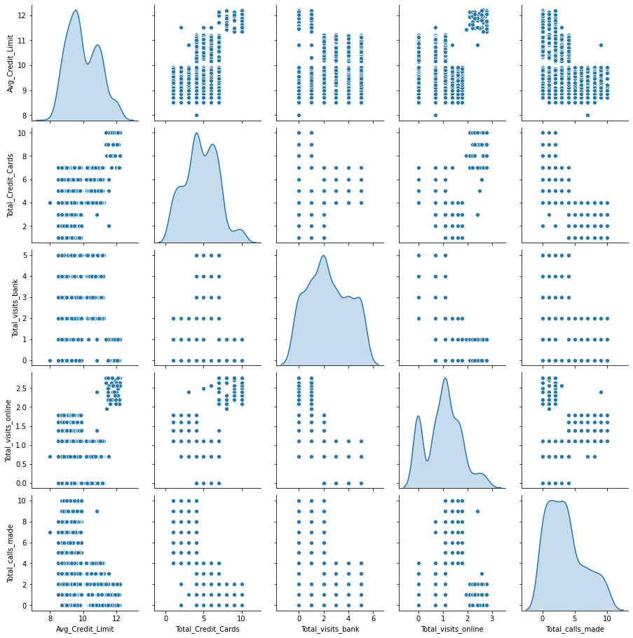

```python
## pairplot

sns.pairplot(df, diag_kind='kde')
plt.show()
```

```python
##Based on the kde plots, we can work with 3 or 4 clusters
```

```python
# correlation matrix
cor=df.corr()
cor
```

|  | Avg_Credit_Limit | Total_Credit_Cards | Total_visits_bank | Total_visits_online | Total_calls_made |
| --- | --- | --- | --- | --- | --- |
| Avg_Credit_Limit | 1.000000 | 0.586248 | 0.073933 | 0.073741 | -0.466310 |
| Total_Credit_Cards | 0.586248 | 1.000000 | 0.315796 | -0.084033 | -0.651251 |
| Total_visits_bank | 0.073933 | 0.315796 | 1.000000 | -0.605344 | -0.506016 |
| Total_visits_online | 0.073741 | -0.084033 | -0.605344 | 1.000000 | 0.326247 |
| Total_calls_made | -0.466310 | -0.651251 | -0.506016 | 0.326247 | 1.000000 |

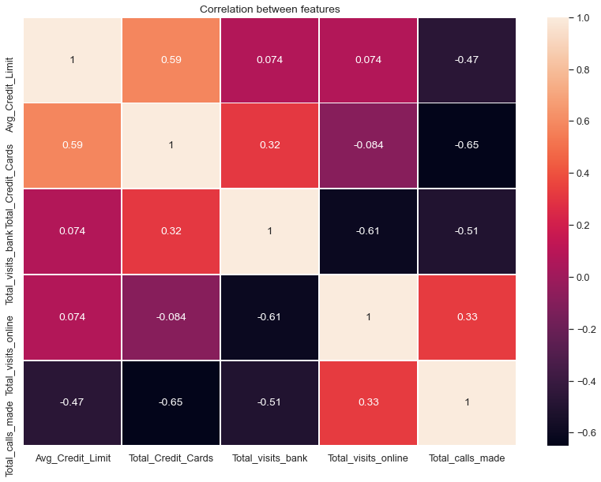

```python
#heatmap

sns.set(font_scale=1.15)
fig, axs = plt.subplots(figsize=(14,10))
sns.heatmap(cor, annot=True, linewidths=.8, ax=axs)
plt.title('Correlation between features');
```

```python
# AVg_Credit_Limit and Total_Credit_Cards are moderatly correlated.
# None of features are not highly correlated. No multicollinearity exist.
```

```python
##Scale the data

from scipy.stats import zscore

df_z = df.apply(zscore)
```

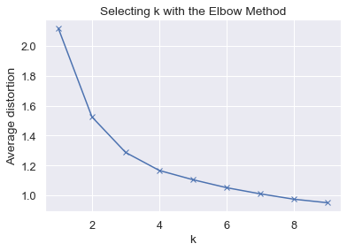

```python
#Finding optimal no. of clusters
from scipy.spatial.distance import cdist
from sklearn.cluster import KMeans

clusters=range(1,10)
meanDistortions=[]

for k in clusters:
    model=KMeans(n_clusters=k)
    model.fit(df_z)
    prediction=model.predict(df_z)
    meanDistortions.append(sum(np.min(cdist(df_z, model.cluster_centers_, 'euclidean'), axis=1)) / df_z.shape[0])


plt.plot(clusters, meanDistortions, 'bx-')
plt.xlabel('k')
plt.ylabel('Average distortion')
plt.title('Selecting k with the Elbow Method')
```

Though the bend is not coming out clearly as there are many bends, let us look at 3 clusters and 4 clusters

```python
# Let us first start with K = 3
final_model=KMeans(3,random_state=100)
final_model.fit(df_z)
prediction=final_model.predict(df_z)
labels = final_model.labels_
#Append the prediction
df["Customer Segments"] = prediction
df_z["Customer Segments"] = prediction
print("Customer Segments Assigned : \n")
df.head()
```

```
Customer Segments Assigned :
```

|  | Avg_Credit_Limit | Total_Credit_Cards | Total_visits_bank | Total_visits_online | Total_calls_made | Customer Segments |
| --- | --- | --- | --- | --- | --- | --- |
| 0 | 11.512935 | 2 | 1 | 0.693147 | 0 | 2 |
| 1 | 10.819798 | 3 | 0 | 2.397895 | 9 | 0 |
| 2 | 10.819798 | 7 | 1 | 1.386294 | 4 | 1 |
| 3 | 10.308986 | 5 | 1 | 0.693147 | 4 | 2 |
| 4 | 11.512935 | 6 | 0 | 2.564949 | 3 | 1 |

```python
# Group the data based on customer segments

dfClust = df.groupby(['Customer Segments'])
dfClust.mean()
```

| Customer Segments | Avg_Credit_Limit | Total_Credit_Cards | Total_visits_bank | Total_visits_online | Total_calls_made |
| --- | --- | --- | --- | --- | --- |
| 0 | 9.316184 | 2.422222 | 0.937778 | 1.476968 | 6.857778 |
| 1 | 11.805801 | 8.705882 | 0.607843 | 2.425783 | 1.137255 |
| 2 | 10.154277 | 5.513021 | 3.500000 | 0.574707 | 1.989583 |

```python
df['Customer Segments'].value_counts()
```

```
2    384
0    225
1     51
Name: Customer Segments, dtype: int64
```

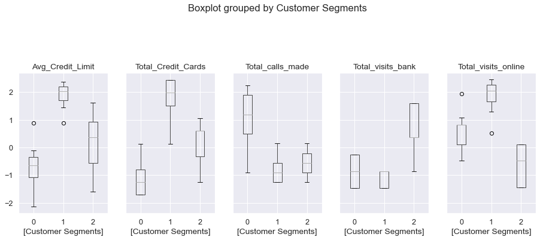

```python
df_z.boxplot(by='Customer Segments', layout = (4,5),figsize=(15,20))
plt.show()
```

# Inferences:

```
i. Customer segment 0 (or) Cluster 0 . Total number of customers= 225. Customer makes more calls to customer service
ii. Customer Segment 1 (or)Cluster 1. Total number of customers= 51.Customer makes more online customer service inquiry and they are high end customers(having max number of credit card and avg credit limt)
iii.Customer segment 2 (or) Cluster 2 . Total number of customers= 384 . Customer makes more bank visits
```

```python
from sklearn.metrics import silhouette_samples, silhouette_score
# Calculating silhouette_score
a= silhouette_score(df_z,labels)
a
```

```
0.5458507817010875
```

```python
Silhouette_coefficients = pd.DataFrame({'Method':['Kmeans Clustering'], 'Cluster': ['3'],'silhouette_score':[a]})
Silhouette_coefficients
```

|  | Method | Cluster | silhouette_score |
| --- | --- | --- | --- |
| 0 | Kmeans Clustering | 3 | 0.545851 |

```python
#  Let us next try with K = 4, the next elbow point
df1= df.drop('Customer Segments',axis=1)
df1_z=df_z.drop('Customer Segments',axis=1)
final_model1=KMeans(4,random_state=100)
final_model1.fit(df1_z)
pred=final_model1.predict(df1_z)
Labels2 = final_model1.labels_
#Append the prediction
df1["Customer Segments"] = pred
df1_z["Customer Segments"] = pred
print("Customer Segments Assigned : \n")
df1.head(10)
```

```
Customer Segments Assigned :
```

|  | Avg_Credit_Limit | Total_Credit_Cards | Total_visits_bank | Total_visits_online | Total_calls_made | Customer Segments |
| --- | --- | --- | --- | --- | --- | --- |
| 0 | 11.512935 | 2 | 1 | 0.693147 | 0 | 3 |
| 1 | 10.819798 | 3 | 0 | 2.397895 | 9 | 0 |
| 2 | 10.819798 | 7 | 1 | 1.386294 | 4 | 3 |
| 3 | 10.308986 | 5 | 1 | 0.693147 | 4 | 3 |
| 4 | 11.512935 | 6 | 0 | 2.564949 | 3 | 1 |
| 5 | 9.903538 | 3 | 0 | 0.693147 | 8 | 0 |
| 6 | 11.512935 | 5 | 0 | 2.484907 | 2 | 1 |
| 7 | 9.615872 | 3 | 0 | 0.693147 | 1 | 0 |
| 8 | 8.517393 | 2 | 0 | 1.098612 | 2 | 0 |
| 9 | 8.006701 | 4 | 0 | 0.693147 | 7 | 0 |

```python
# grouping the data based on customer segment when cluster =4

df1Clust = df1.groupby(['Customer Segments'])
df1Clust.mean()
```

| Customer Segments | Avg_Credit_Limit | Total_Credit_Cards | Total_visits_bank | Total_visits_online | Total_calls_made |
| --- | --- | --- | --- | --- | --- |
| 0 | 9.318248 | 2.410714 | 0.933036 | 1.478658 | 6.870536 |
| 1 | 11.825521 | 8.740000 | 0.600000 | 2.446572 | 1.080000 |
| 2 | 9.334426 | 5.473054 | 3.604790 | 0.586343 | 1.928144 |
| 3 | 10.776560 | 5.547945 | 3.401826 | 0.571933 | 2.054795 |

```python
df1['Customer Segments'].value_counts()
```

```
0    224
3    219
2    167
1     50
Name: Customer Segments, dtype: int64
```

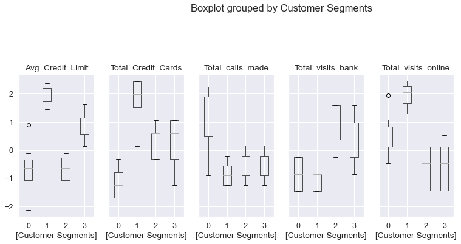

```python
df1_z.boxplot(by='Customer Segments', layout = (4,6),figsize=(15,20))
plt.show()
```

Inferences:

```
i. Customer segment 0 (or) Cluster 0 . Total number of customers= 224. Customer makes more calls to customer service
ii. Customer Segment 1 (or)Cluster 1. Total number of customers= 50. Customer makes more online customer service inquiry and they are high end customers(having max number of credit card and avg credit limt)
iii.Customer segment 2 (or) Cluster 2 . Total number of customers= 167 . Customer makes more bank visits
iv.Customer segment 3 (or) Cluster 3 . Total number of customers= 219 . Customer makes more bank visits . Cluster 2 and Cluster 3 characteristics are almost similar
```

```python
# Calculating silhouette_score
b= silhouette_score(df1_z,Labels2)
b
```

```
0.4442397982362169
```

```python
Silhouette_coefficient = pd.DataFrame({'Method':['Kmeans Clustering'], 'Cluster': ['4'],'silhouette_score':[b]})
Silhouette_coefficients
Silhouette_coefficients = pd.concat([Silhouette_coefficients, Silhouette_coefficient])
```

```python
Silhouette_coefficients
```

|  | Method | Cluster | silhouette_score |
| --- | --- | --- | --- |
| 0 | Kmeans Clustering | 3 | 0.545851 |
| 0 | Kmeans Clustering | 4 | 0.444240 |

#### Kmeans clustering Inferences:

1. silhouette score=0.545 when cluster=3
2. Silhouette score =0.444 when cluster=4.
3. Best model should have silhouette score nearer to +1. By considering this fact, best clustering model is when cluster/k=3

# Hierrarchial Clustering

```python
H_df=df.drop('Customer Segments',axis=1)
H_df_z=df_z.drop('Customer Segments',axis=1)
```

```python
#### generate the linkage matrix using ward linkage
from scipy.cluster.hierarchy import cophenet,dendrogram, linkage
from scipy.spatial.distance import pdist
Z1 = linkage(H_df_z, 'ward', metric='euclidean')

c1, coph_dists1 = cophenet(Z1 , pdist(H_df_z))

c1
```

```
0.7646785809375133
```

```python
# Cophenet score

cophenet_scores = pd.DataFrame({'Method':['Ward Linkage'], 'Cophenet_Scores': [c1]})
cophenet_scores
```

|  | Method | Cophenet_Scores |
| --- | --- | --- |
| 0 | Ward Linkage | 0.764679 |

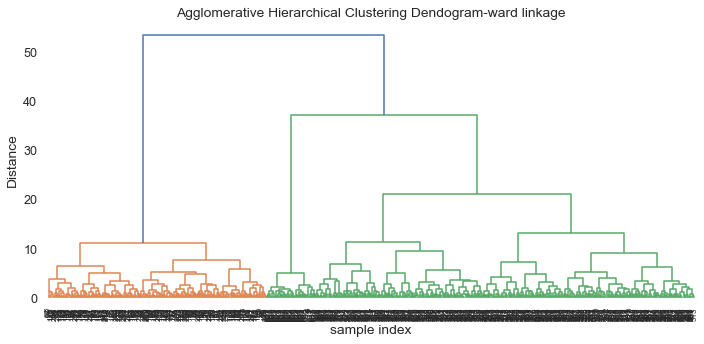

```python
plt.figure(figsize=(10, 5))
plt.title('Agglomerative Hierarchical Clustering Dendogram-ward linkage')
plt.xlabel('sample index')
plt.ylabel('Distance')
dendrogram(Z1, leaf_rotation=90.,color_threshold = 40, leaf_font_size=8. )
plt.tight_layout()
```

```python
#### generate the linkage matrix using single linkage
from scipy.cluster.hierarchy import cophenet,dendrogram, linkage
from scipy.spatial.distance import pdist
Z2 = linkage(H_df_z, 'single', metric='euclidean')

c2, coph_dists2 = cophenet(Z2 , pdist(H_df_z))

c2
```

```
0.6183509759772005
```

```python
# Cophenet score

cophenet_score = pd.DataFrame({'Method':['Single Linkage'], 'Cophenet_Scores': [c2]})
cophenet_scores = pd.concat([cophenet_scores, cophenet_score])
cophenet_scores
```

|  | Method | Cophenet_Scores |
| --- | --- | --- |
| 0 | Ward Linkage | 0.764679 |
| 0 | Single Linkage | 0.618351 |

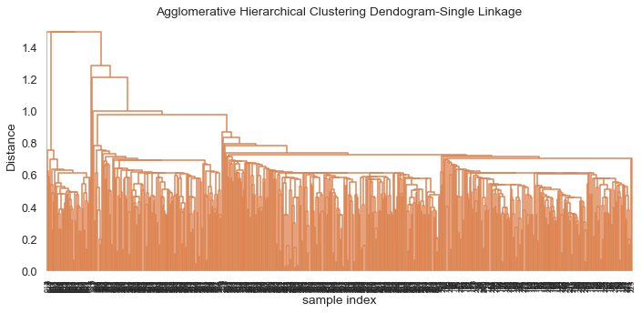

```python
plt.figure(figsize=(10, 5))
plt.title('Agglomerative Hierarchical Clustering Dendogram-Single Linkage')
plt.xlabel('sample index')
plt.ylabel('Distance')
dendrogram(Z2, leaf_rotation=90.,color_threshold = 40, leaf_font_size=8. )
plt.tight_layout()
```

```python
#### generate the linkage matrix using Complete linkage
from scipy.cluster.hierarchy import cophenet,dendrogram, linkage
from scipy.spatial.distance import pdist
Z3 = linkage(H_df_z, 'complete', metric='euclidean')
c3, coph_dists3 = cophenet(Z3 , pdist(H_df_z))

c3
```

```
0.8100445399908286
```

```python
# Cophenet score

cophenet_score = pd.DataFrame({'Method':['Complete Linkage'], 'Cophenet_Scores': [c3]})
cophenet_scores = pd.concat([cophenet_scores, cophenet_score])
cophenet_scores
```

|  | Method | Cophenet_Scores |
| --- | --- | --- |
| 0 | Ward Linkage | 0.764679 |
| 0 | Single Linkage | 0.618351 |
| 0 | Complete Linkage | 0.810045 |

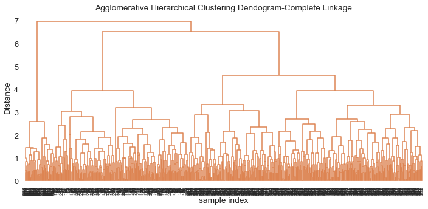

```python
plt.figure(figsize=(10, 5))
plt.title('Agglomerative Hierarchical Clustering Dendogram-Complete Linkage')
plt.xlabel('sample index')
plt.ylabel('Distance')
dendrogram(Z3, leaf_rotation=90.,color_threshold = 40, leaf_font_size=8. )
plt.tight_layout()
```

```python
#### generate the linkage matrix using Average linkage
from scipy.cluster.hierarchy import cophenet,dendrogram, linkage
from scipy.spatial.distance import pdist
Z4 = linkage(H_df_z, 'average', metric='euclidean')
c4, coph_dists4 = cophenet(Z4 , pdist(H_df_z))
c4
```

```
0.84927473667065
```

```python
# Cophenet score

cophenet_score = pd.DataFrame({'Method':['Average Linkage'], 'Cophenet_Scores': [c4]})
cophenet_scores = pd.concat([cophenet_scores, cophenet_score])
cophenet_scores
```

|  | Method | Cophenet_Scores |
| --- | --- | --- |
| 0 | Ward Linkage | 0.764679 |
| 0 | Single Linkage | 0.618351 |
| 0 | Complete Linkage | 0.810045 |
| 0 | Average Linkage | 0.849275 |

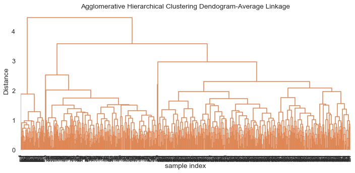

```python
plt.figure(figsize=(10, 5))
plt.title('Agglomerative Hierarchical Clustering Dendogram-Average Linkage')
plt.xlabel('sample index')
plt.ylabel('Distance')
dendrogram(Z4, leaf_rotation=90.,color_threshold = 40, leaf_font_size=8. )
plt.tight_layout()
```

```python
#### generate the linkage matrix using Centriod linkage
from scipy.cluster.hierarchy import cophenet,dendrogram, linkage
from scipy.spatial.distance import pdist
Z5 = linkage(H_df_z, 'centroid', metric='euclidean')
c5, coph_dists = cophenet(Z5 , pdist(H_df_z))
c5
```

```
0.8433942159657706
```

```python
# Cophenet score

cophenet_score = pd.DataFrame({'Method':['Centroid Linkage'], 'Cophenet_Scores': [c5]})
cophenet_scores = pd.concat([cophenet_scores, cophenet_score])
cophenet_scores
```

|  | Method | Cophenet_Scores |
| --- | --- | --- |
| 0 | Ward Linkage | 0.764679 |
| 0 | Single Linkage | 0.618351 |
| 0 | Complete Linkage | 0.810045 |
| 0 | Average Linkage | 0.849275 |
| 0 | Centroid Linkage | 0.843394 |

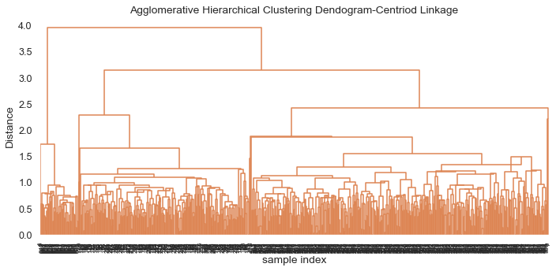

```python
plt.figure(figsize=(10, 5))
plt.title('Agglomerative Hierarchical Clustering Dendogram-Centriod Linkage')
plt.xlabel('sample index')
plt.ylabel('Distance')
dendrogram(Z5, leaf_rotation=90.,color_threshold = 40, leaf_font_size=8. )
plt.tight_layout()
```

```python
#### generate the linkage matrix using Weighted linkage
from scipy.cluster.hierarchy import cophenet,dendrogram, linkage
from scipy.spatial.distance import pdist
Z6 = linkage(H_df_z, 'weighted', metric='euclidean')
c6, coph_dists = cophenet(Z6 , pdist(H_df_z))
c6
```

```
0.8374691111194833
```

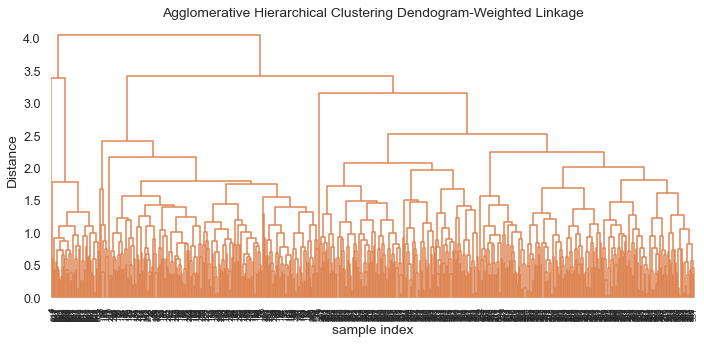

```python
plt.figure(figsize=(10, 5))
plt.title('Agglomerative Hierarchical Clustering Dendogram-Weighted Linkage')
plt.xlabel('sample index')
plt.ylabel('Distance')
dendrogram(Z6, leaf_rotation=90.,color_threshold = 40, leaf_font_size=8. )
plt.tight_layout()
```

```python
# Cophenet score

cophenet_score = pd.DataFrame({'Method':['Weighted Linkage'], 'Cophenet_Scores': [c6]})
cophenet_scores = pd.concat([cophenet_scores, cophenet_score])
a1=cophenet_scores.reset_index()
cophenet_scores=a1.drop('index', axis=1).sort_values(by=['Cophenet_Scores'],ascending=False)

cophenet_scores
```

|  | Method | Cophenet_Scores |
| --- | --- | --- |
| 3 | Average Linkage | 0.849275 |
| 4 | Centroid Linkage | 0.843394 |
| 5 | Weighted Linkage | 0.837469 |
| 2 | Complete Linkage | 0.810045 |
| 0 | Ward Linkage | 0.764679 |
| 1 | Single Linkage | 0.618351 |

Inference: For better hierarchial clustering, Cophenet value should be closer to 1. By considering this fact, average linkage returns higher cophent score compared to all other linkage methods for this dataset

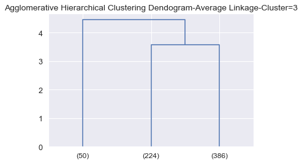

```python
# drawing average linkage dendogram with cluser =3

dendrogram(
    Z4,
    truncate_mode='lastp',  # show only the last p merged clusters
    p=3,  # show only the last p merged clusters
)
plt.title('Agglomerative Hierarchical Clustering Dendogram-Average Linkage-Cluster=3')
```

```python
from sklearn.cluster import AgglomerativeClustering
```

```python
model = AgglomerativeClustering(n_clusters=3, affinity='euclidean',  linkage='average')
```

```python
model.fit(H_df_z)
```

```
AgglomerativeClustering(linkage='average', n_clusters=3)
```

```python
model.labels_
```

[output not shown]

```python
H_df['Customer Segments'] = model.labels_
H_df_z['Customer Segments'] = model.labels_
Label3=model.labels_
H_df.head(5)
```

|  | Avg_Credit_Limit | Total_Credit_Cards | Total_visits_bank | Total_visits_online | Total_calls_made | Customer Segments |
| --- | --- | --- | --- | --- | --- | --- |
| 0 | 11.512935 | 2 | 1 | 0.693147 | 0 | 0 |
| 1 | 10.819798 | 3 | 0 | 2.397895 | 9 | 2 |
| 2 | 10.819798 | 7 | 1 | 1.386294 | 4 | 0 |
| 3 | 10.308986 | 5 | 1 | 0.693147 | 4 | 0 |
| 4 | 11.512935 | 6 | 0 | 2.564949 | 3 | 1 |

```python
H_dfClust = H_df.groupby(['Customer Segments'])
H_dfClust.mean()
```

| Customer Segments | Avg_Credit_Limit | Total_Credit_Cards | Total_visits_bank | Total_visits_online | Total_calls_made |
| --- | --- | --- | --- | --- | --- |
| 0 | 10.154606 | 5.510363 | 3.484456 | 0.577117 | 1.992228 |
| 1 | 11.825521 | 8.740000 | 0.600000 | 2.446572 | 1.080000 |
| 2 | 9.314846 | 2.419643 | 0.941964 | 1.480468 | 6.883929 |

```python
H_df['Customer Segments'].value_counts()
```

```
0    386
2    224
1     50
Name: Customer Segments, dtype: int64
```

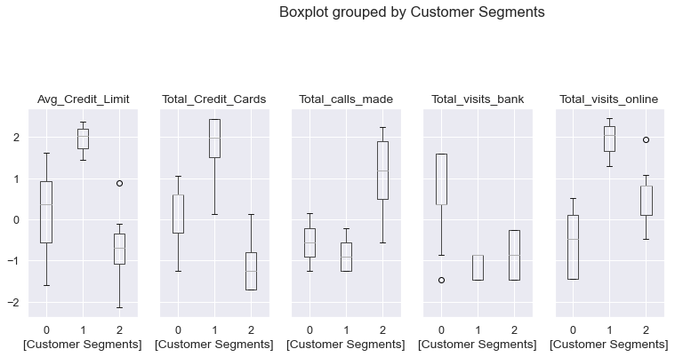

```python
# Visualizing average linkage dendogram with cluser =3
H_df_z.boxplot(by='Customer Segments', layout = (4,6),figsize=(15,20))
plt.show()
```

Inferences:

i. Customer segment 0 (or) Cluster 0 . Total number of customers= 386 . Customer makes more bank visits

ii. Customer Segment 1 (or)Cluster 1. Total number of customers= 50.Customer makes more online customer service inquiry and they are high end customers(having max number of credit card and avg credit limt)

iii. Customer segment 2 (or) Cluster 2 . Total number of customers= 224. Customer makes more calls to customer service

```python
#calcualting silhouette score when cluster =3

c=silhouette_score(H_df_z,Label3)
c
```

```
0.5464996018810389
```

```python
Silhouette_coefficient = pd.DataFrame({'Method':['Hierarchical Clustering'], 'Cluster': ['3'],'silhouette_score':[c]})
Silhouette_coefficients = pd.concat([Silhouette_coefficients, Silhouette_coefficient])
Silhouette_coefficients
```

|  | Method | Cluster | silhouette_score |
| --- | --- | --- | --- |
| 0 | Kmeans Clustering | 3 | 0.545851 |
| 0 | Kmeans Clustering | 4 | 0.444240 |
| 0 | Hierarchical Clustering | 3 | 0.546500 |

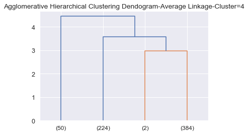

```python
# Visualizing average linkage dendogram with cluser =4

dendrogram(
    Z4,
    truncate_mode='lastp',  # show only the last p merged clusters
    p=4,  # show only the last p merged clusters
)
plt.title('Agglomerative Hierarchical Clustering Dendogram-Average Linkage-Cluster=4')
```

```python
model1 = AgglomerativeClustering(n_clusters=4, affinity='euclidean',  linkage='average')
```

```python
H_df1_z=H_df_z.drop('Customer Segments',axis=1)
H_df1=H_df.drop('Customer Segments',axis=1)
```

```python
model1.fit(H_df1_z)
```

```
AgglomerativeClustering(linkage='average', n_clusters=4)
```

```python
H_df1['Customer Segments'] = model1.labels_
H_df1_z['Customer Segments'] = model1.labels_
Label4=model1.labels_
H_df1.head()
```

|  | Avg_Credit_Limit | Total_Credit_Cards | Total_visits_bank | Total_visits_online | Total_calls_made | Customer Segments |
| --- | --- | --- | --- | --- | --- | --- |
| 0 | 11.512935 | 2 | 1 | 0.693147 | 0 | 1 |
| 1 | 10.819798 | 3 | 0 | 2.397895 | 9 | 0 |
| 2 | 10.819798 | 7 | 1 | 1.386294 | 4 | 2 |
| 3 | 10.308986 | 5 | 1 | 0.693147 | 4 | 2 |
| 4 | 11.512935 | 6 | 0 | 2.564949 | 3 | 3 |

```python
H_df1Clust = H_df1.groupby(['Customer Segments'])
H_df1Clust.mean()
```

| Customer Segments | Avg_Credit_Limit | Total_Credit_Cards | Total_visits_bank | Total_visits_online | Total_calls_made |
| --- | --- | --- | --- | --- | --- |
| 0 | 9.314846 | 2.419643 | 0.941964 | 1.480468 | 6.883929 |
| 1 | 10.564404 | 2.500000 | 0.500000 | 0.693147 | 0.500000 |
| 2 | 10.152472 | 5.526042 | 3.500000 | 0.576512 | 2.000000 |
| 3 | 11.825521 | 8.740000 | 0.600000 | 2.446572 | 1.080000 |

```python
H_df1['Customer Segments'].value_counts()
```

```
2    384
0    224
3     50
1      2
Name: Customer Segments, dtype: int64
```

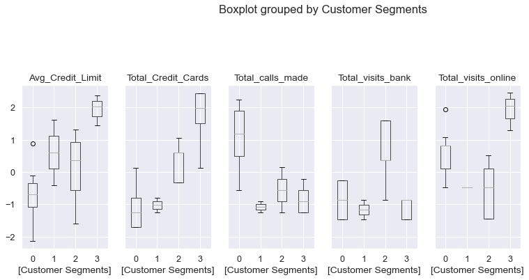

```python
H_df1_z.boxplot(by='Customer Segments', layout = (4,6),figsize=(15,20))
plt.show()
```

Inferences:

i. Customer segment 0 (or) Cluster 0 . Total number of customers= 224. Customer makes more calls to customer service

ii. Customer Segment 1 (or)Cluster 1. Total number of customers= 2

iii.Customer segment 2 (or) Cluster 2 . Total number of customers= 384 . Customer makes more bank visits

iv. Customer Segment 3 (or)Cluster 3. Total number of customers= 50. Customer makes more online customer service inquiry and they are high end customers(having max number of credit card and avg credit limt)

```python
d=silhouette_score(H_df1_z,Label4)
d
```

```
0.4339125243394371
```

```python
Silhouette_coefficient = pd.DataFrame({'Method':['Hierarchical Clustering'], 'Cluster': ['4'],'silhouette_score':[d]})
Silhouette_coefficients = pd.concat([Silhouette_coefficients, Silhouette_coefficient])
a=Silhouette_coefficients.reset_index()
silhouette_coefficients=a.drop('index', axis=1)
silhouette_coefficients
```

|  | Method | Cluster | silhouette_score |
| --- | --- | --- | --- |
| 0 | Kmeans Clustering | 3 | 0.545851 |
| 1 | Kmeans Clustering | 4 | 0.444240 |
| 2 | Hierarchical Clustering | 3 | 0.546500 |
| 3 | Hierarchical Clustering | 4 | 0.433913 |

Inference: Silhouette score is better for both Kmeans clustering and hierrarchial clustering when cluster=3

#### Hierarchial vs K-Means Clustering comparison

1. We have almost similar silhouette score for both Kmeans and agglomerative clusters of size 3
2. we have the best result for the agglomerative Hierarchial clustering using the average linkage method as the cophenet index seems to be the highest amongest all the other linkage methods
3. Shape of Clusters are almost similar. this may be due to smaller dataset. we may observe difference in cluster shape if our dataset is bigger

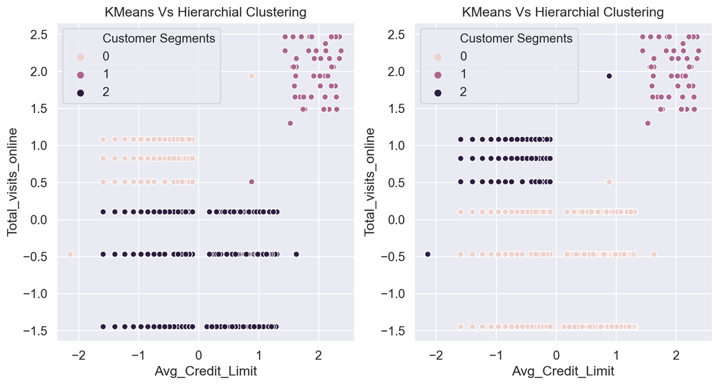

```python
# Scatter plot visualization

plt.figure(figsize=(12,6),dpi=200)

plt.subplot(1,2,1)
sns.scatterplot(x='Avg_Credit_Limit' , y='Total_visits_online',data=df_z,hue='Customer Segments')
plt.title('KMeans Vs Hierarchial Clustering')

plt.subplot(1,2,2)
sns.scatterplot(x='Avg_Credit_Limit', y='Total_visits_online',data=H_df_z,hue='Customer Segments')
plt.title('KMeans Vs Hierarchial Clustering')
plt.show()
```

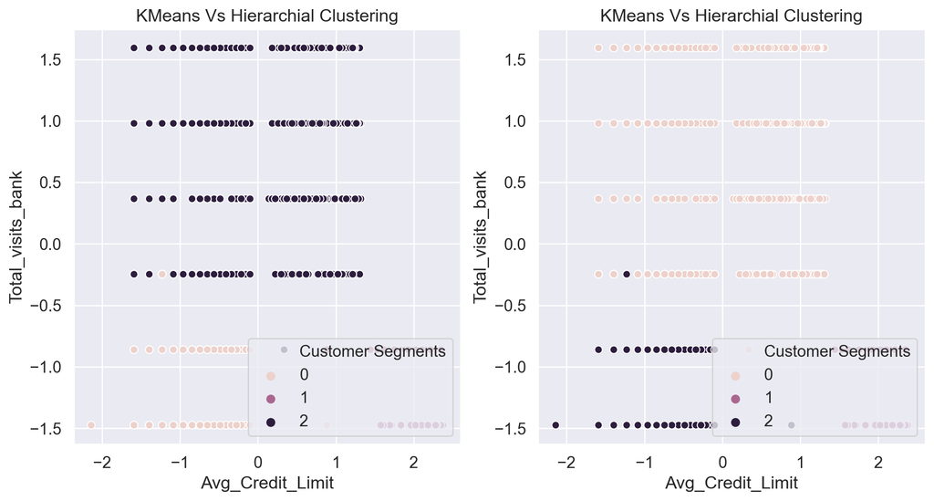

```python
# Scatter plot visualization

plt.figure(figsize=(12,6),dpi=200)

plt.subplot(1,2,1)
sns.scatterplot(x='Avg_Credit_Limit' , y='Total_visits_bank',data=df_z,hue='Customer Segments')
plt.title('KMeans Vs Hierarchial Clustering')

plt.subplot(1,2,2)
sns.scatterplot(x='Avg_Credit_Limit', y='Total_visits_bank',data=H_df_z,hue='Customer Segments')
plt.title('KMeans Vs Hierarchial Clustering')
plt.show()
```

```python
#K-mean clustering with cluster =3
dfClust.mean()
```

| Customer Segments | Avg_Credit_Limit | Total_Credit_Cards | Total_visits_bank | Total_visits_online | Total_calls_made |
| --- | --- | --- | --- | --- | --- |
| 0 | 9.316184 | 2.422222 | 0.937778 | 1.476968 | 6.857778 |
| 1 | 11.805801 | 8.705882 | 0.607843 | 2.425783 | 1.137255 |
| 2 | 10.154277 | 5.513021 | 3.500000 | 0.574707 | 1.989583 |

```python
# Hierarchial clustering with cluster =3
H_dfClust.mean()
```

| Customer Segments | Avg_Credit_Limit | Total_Credit_Cards | Total_visits_bank | Total_visits_online | Total_calls_made |
| --- | --- | --- | --- | --- | --- |
| 0 | 10.154606 | 5.510363 | 3.484456 | 0.577117 | 1.992228 |
| 1 | 11.825521 | 8.740000 | 0.600000 | 2.446572 | 1.080000 |
| 2 | 9.314846 | 2.419643 | 0.941964 | 1.480468 | 6.883929 |

1. How many different segments of customers are there?

   Customers can be broadly segmented into 3 Customer segments.
   1. Based on Avg Credit Card Limit,
   2. Based on number of credit cards
   3. Based on their interaction with customer services.
1. How are these segments different from each other?

   These segments are different from each other based on their credit limit, number of credit cards owned and how they interact with the banks customer services.
1. What are your recommendations to the bank on how to better market to and service these customers?
   1. The recommendations to the bank is to have different strategies to retain and increase customer value by target low value customers (less than 3 credit card) with marketing strategies to increase their credit limits and offer incentives to acquire more credit cards. Also since these customers are primarily interacting with the bank over calls to the customer service center, an improved customer experience on the calls will help retain them and increase value.
   2. For customers who are in the mid range value (Less than 6 credit cards) who prefer to visit the bank and interact directly with the bank, to focus marketing strategy to up-sell more when they visit the bank and also provide better experience at the bank location
   3. for customers who are high value (greater than 6 credit cards) who prefer to interact using online method, the bank can focus on improving their experience online and upsell other services and ensure that these customers are retained and remain as customer